# STAC33 Final Exam - Bo Han Wang

```r
library(tidyverse)
library(broom)
```

## 1.

# a)

```r
my_url <- "http://ritsokiguess.site/STAC33/winecellar.csv"
wined <- read_csv(my_url)
wined
```

| country_region | vintage | product_name | consumption |
| --- | --- | --- | --- |
| ALSACE | 2007 | Alsace Pinot Gris Les Elements Dom. Bott Geyl 2007 | 5.00 |
| ALSACE | 2007 | Riesling Domaine Marcel Deiss | 4.00 |
| ALSACE | 2008 | Pinot Gris Domaine Rolly Gassmann | 8.00 |
| ALSACE | 2010 | Gewurtztraminer Les Princes Abbes Dom Schlumberger | 17.00 |
| AUSTRALIA | 1995 | Lindemanns Pyrus | 2.00 |
| AUSTRALIA | 1999 | Eileen Hardy Shiraz | 1.00 |
| AUSTRALIA | 2002 | D'Arenberg The Coppermine Road | 1.00 |
| AUSTRALIA | 2002 | Giaconda Shiraz Warner Vineyard | 3.00 |
| AUSTRALIA | 2002 | Katnook Prodicy Shiraz Coonawarra | 3.00 |
| AUSTRALIA | 2008 | Moss Wood Chardonnay Margaret River | 10.00 |

[output cut: 189 more lines]

# b)

```r
wined %>% select(product_name)
```

| product_name |
| --- |
| Alsace Pinot Gris Les Elements Dom. Bott Geyl 2007 |
| Riesling Domaine Marcel Deiss |
| Pinot Gris Domaine Rolly Gassmann |
| Gewurtztraminer Les Princes Abbes Dom Schlumberger |
| Lindemanns Pyrus |
| Eileen Hardy Shiraz |
| D'Arenberg The Coppermine Road |
| Giaconda Shiraz Warner Vineyard |
| Katnook Prodicy Shiraz Coonawarra |
| Moss Wood Chardonnay Margaret River |

[output cut: 189 more lines]

# c)

```r
wined %>% filter(country_region == "LOIRE")
```

| country_region | vintage | product_name | consumption |
| --- | --- | --- | --- |
| LOIRE | 2002 | Pouilly =-Fume Chateau de Tracey | 4 |
| LOIRE | 2006 | Sancerre Roland Tissiere | 3 |
| LOIRE | 2010 | Sancerre Nuance Vincent Pinard | 4 |
| LOIRE | 2010 | Sancerre Dom Vacheron | 6 |

# d)

```r
wined %>% group_by(vintage) %>% summarize(wine_number = n())
```

| vintage | wine_number |
| --- | --- |
| 1921 | 1 |
| 1948 | 1 |
| 1960 | 1 |
| 1967 | 1 |
| 1975 | 1 |
| 1977 | 3 |
| 1979 | 1 |
| 1981 | 1 |
| 1982 | 1 |
| 1983 | 3 |

[output cut: 30 more lines]

# e)

```r
wined %>%
  group_by(vintage) %>%
  summarize(sub_consumpion = sum(consumption)) -> wined2
wined2
```

| vintage | sub_consumpion |
| --- | --- |
| 1921 | 0.75 |
| 1948 | 0.50 |
| 1960 | 0.25 |
| 1967 | 1.00 |
| 1975 | 2.00 |
| 1977 | 12.00 |
| 1979 | 1.00 |
| 1981 | 1.00 |
| 1982 | 1.00 |
| 1983 | 12.00 |

[output cut: 30 more lines]

# f)

```r
wined2 %>% arrange(desc(sub_consumpion))
```

| vintage | sub_consumpion |
| --- | --- |
| 2014/15 | 1637.00 |
| 2016 | 836.00 |
| 2010 | 407.00 |
| 2000 | 112.00 |
| 1990 | 92.00 |
| 2013 | 87.00 |
| N/A | 86.25 |
| 2006 | 83.00 |
| 2007 | 73.00 |
| 2008 | 65.00 |

[output cut: 30 more lines]

As shown from the data, 2014/15 vintage has 1637 wine consummed.

# g)

```r
wined %>% filter(country_region == "AUSTRALIA") %>%
  group_by(country_region) %>%
  summarize(total = sum(consumption))
```

| country_region | total |
| --- | --- |
| AUSTRALIA | 25 |

In total, there are 25 bottles of wine from Australia were consumped.

## 2.

# a)

```r
my_url <- "http://ritsokiguess.site/STAC33/bank.csv"
bank <- read_csv(my_url)
bank
```

| within | morning_phone | morning_teller | afternoon_phone | afternoon_teller | evening_phone | evening_teller |
| --- | --- | --- | --- | --- | --- | --- |
| 1 | 6 | 8 | 3 | 9 | 5 | 9 |
| 2 | 5 | 7 | 5 | 10 | 5 | 10 |
| 3 | 8 | 9 | 6 | 6 | 7 | 10 |
| 4 | 4 | 9 | 5 | 8 | 5 | 9 |

# b)

The data is not tidy since all the time periods (i.e. morning, afternoon, evening) are within one day but being put into multiple columns.These column names make the data hard to be specified. It is hard to make plots and tests.

# c)

```r
bank2 <- bank %>%
  pivot_longer(morning_phone:evening_teller, names_to = "contact_time", values_to = "satisfication") %>%
  separate(contact_time, c("time", "contact"), "_")
bank2
```

| within | time | contact | satisfication |
| --- | --- | --- | --- |
| 1 | morning | phone | 6 |
| 1 | morning | teller | 8 |
| 1 | afternoon | phone | 3 |
| 1 | afternoon | teller | 9 |
| 1 | evening | phone | 5 |
| 1 | evening | teller | 9 |
| 2 | morning | phone | 5 |
| 2 | morning | teller | 7 |
| 2 | afternoon | phone | 5 |
| 2 | afternoon | teller | 10 |

[output cut: 14 more lines]

# d)

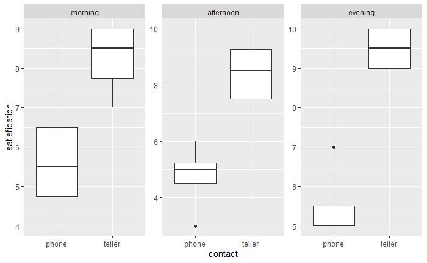

```r
bank2 %>% ggplot(aes(x = contact, y = satisfication)) +
  geom_boxplot() +
  facet_wrap(~fct_inorder(time), scale = "free")
```

# e)

From the graph, it is obvious that the median of teller is graeter than the median of phone in each group. Thus customers are preferred to be contact by teller.Evening seems to be the best of 3 times since the teller boxplot with highest median and no whiskers.

# f)

```r
my_url = "http://ritsokiguess.site/STAC33/bank_original.csv"
newbank <- read_csv(my_url)
newbank
```

| timeofday | phone | teller |
| --- | --- | --- |
| morning | 6:5:8:4 | 8:7:9:9 |
| afternoon | 3:5:6:5 | 9:10:6:8 |
| evening | 5:5:7:5 | 9:10:10:9 |

# g)

```r
newbank %>%
  pivot_longer(phone:teller, names_to = "contact", values_to = "satisfication") %>%
  separate(satisfication, c("1", "2", "3", "4"), ":") %>%
  pivot_longer("1":"4", names_to = "within", values_to = "satisfication") %>%
  select(within, time = timeofday, contact, satisfication) %>%
  arrange(within)
```

| within | time | contact | satisfication |
| --- | --- | --- | --- |
| 1 | morning | phone | 6 |
| 1 | morning | teller | 8 |
| 1 | afternoon | phone | 3 |
| 1 | afternoon | teller | 9 |
| 1 | evening | phone | 5 |
| 1 | evening | teller | 9 |
| 2 | morning | phone | 5 |
| 2 | morning | teller | 7 |
| 2 | afternoon | phone | 5 |
| 2 | afternoon | teller | 10 |

[output cut: 14 more lines]

## 3.

# a)

```r
my_url = "http://ritsokiguess.site/STAC33/allgreen.txt"
business <- read_delim(my_url, " ")
business
```

| sales | display | inventory | advertising | sales_size | competing |
| --- | --- | --- | --- | --- | --- |
| 231.0 | 3.0 | 294 | 8.2 | 8.2 | 11 |
| 156.0 | 2.2 | 232 | 6.9 | 4.1 | 12 |
| 10.0 | 0.5 | 149 | 3.0 | 4.3 | 15 |
| 519.0 | 5.5 | 600 | 12.0 | 16.3 | 1 |
| 437.0 | 4.4 | 567 | 10.5 | 14.1 | 5 |
| 487.0 | 4.8 | 571 | 11.8 | 12.7 | 4 |
| 299.0 | 3.1 | 512 | 8.1 | 10.1 | 10 |
| 195.0 | 2.5 | 347 | 7.7 | 8.4 | 12 |
| 20.0 | 1.2 | 212 | 3.3 | 2.1 | 15 |
| 68.0 | 0.6 | 102 | 4.9 | 4.7 | 8 |

[output cut: 17 more lines]

# b)

```r
business.1 <- lm(sales~display + inventory + advertising + sales_size + competing, data = business)
summary(business.1)
```

```
Call:
lm(formula = sales ~ display + inventory + advertising + sales_size +
    competing, data = business)

Residuals:
    Min      1Q  Median      3Q     Max
-25.795 -10.297  -4.299   5.002  40.938

Coefficients:
             Estimate Std. Error t value Pr(>|t|)
(Intercept) -13.75392   30.91717  -0.445 0.660970
display      16.41732    3.65879   4.487 0.000203 ***
inventory     0.17594    0.05955   2.954 0.007572 **
advertising  11.43898    2.61496   4.374 0.000265 ***
sales_size   13.21008    1.80256   7.328 3.26e-07 ***
competing    -5.54914    1.75254  -3.166 0.004653 **
---
Signif. codes:  0 ‘***’ 0.001 ‘**’ 0.01 ‘*’ 0.05 ‘.’ 0.1 ‘ ’ 1

Residual standard error: 18.25 on 21 degrees of freedom
Multiple R-squared:  0.9927,    Adjusted R-squared:  0.991
F-statistic: 571.7 on 5 and 21 DF,  p-value: < 2.2e-16
```

# c)

Based on the summary of b), it is clear that all the variables have p-values stricly less than 0.05. Thus all variables are significantly different from 0, which then cannot be eliminated. Besides, adjusted R-square is about 99% which indicate that the model is being fitted well. There’s no need to modify the model.

# d)

Competing shows a negative slope is reasonable.As competing increase by a unit, intercept drop by 5.54914 units. If a store have good display; inventory; advertiseing and sales_size, it is possible for them to be at a disadvantage on competing with other stores (maybe the sotre just opened for business).

# e)

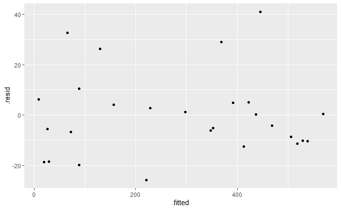

```r
business.1 %>% ggplot(aes(x = .fitted, y = .resid)) + geom_point()
```

# f)

The plot seems randomly scattered, no pattern could be observed then this indicate that the fitted model is a good assumption.

# g)

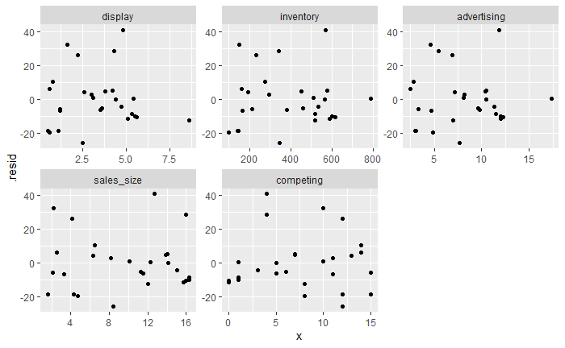

```r
business.1 %>% augment(business) -> business2
business2 %>%
  pivot_longer(display:competing, names_to = "xname", values_to = "x") %>%
  ggplot(aes(x = x, y = .resid)) + geom_point() + facet_wrap(~fct_inorder(xname), scale = "free")
```

# h)

Based on the plots of g), there seems no pattern on any residual against each variable’s value. Thus the plot is completely random and the model is fitted well. However the graph e) is really similar to residual vs sales_size in g). Thus it is indicating that sales_size is having a relatively larger correlation when comparing to other variables.

## 4.

# a)

```r
my_url = "http://ritsokiguess.site/STAC33/zz.csv"
estimate <- read_csv(my_url)
estimate
```

| z |
| --- |
| 9.9025605 |
| 2.1675281 |
| 6.1616814 |
| 2.0937391 |
| 6.2565840 |
| 1.5314216 |
| 5.7367261 |
| 2.9161783 |
| 16.6776902 |
| 1.9393908 |

[output cut: 90 more lines]

# b)

Since the data has 100 sample on variable z, then df = 100 - 1 = 99

```r
n <- length(estimate$z)
ba <- qchisq(c(0.975, 0.025), df = n - 1)
ba
```

```
[1] 128.42199  73.36108
```

a = 73.36108, b = 128.42199

# c)

```r
#estimate %>% mutate(m = mean(z)) -> est
#m <- est$m
#ssq2 <- sum((estimate$z - m)^2)/(n - 1)
#ssq2
# the above was manually calculating sample variance
ssq <- var(estimate$z)
sigmasq <- ((n-1)*ssq)/ba
sigmasq
```

```
[1]  9.888232 17.309811
```

# d)

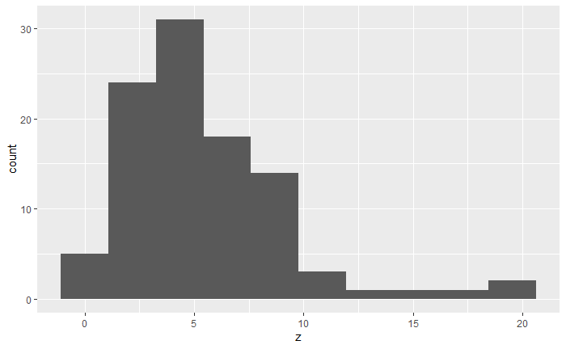

```r
estimate %>% ggplot(aes(x = z)) + geom_histogram(bins = 10)
```

# e)

Based on the plot, the 95% CI seems to be at around (5, 15) however in c) it’s (9.888232, 17.309811) indicating that the interval is very narrow which is doubtable.

# f)

```r
rerun(1000, sample(estimate$z, replace = T)) %>%
  map_dbl(~ var(.)) -> vars
b_CI <- quantile(vars, c(0.025, 0.975))
b_CI
```

```
     2.5%     97.5%
 7.005251 19.700926
```

# g)

```r
tibble(sigmasq, b_CI)
```

| sigmasq | b_CI |
| --- | --- |
| 9.888232 | 7.005251 |
| 17.309811 | 19.700926 |